# Projet_PCA

Ousmane DIA:Master I:BDA

7/04/2022

## Analyse en Composantes Principales (ACP) des données Covid-data des pays africains

## I-Prétraitement des données

### 1-Chargement des données

```r
# data=read.csv2("~/Documents/Master Big Data/Apprentissage non supervisé/Projet 1/covid-data.csv")
data=read.table("~/Documents/Master Big Data/Apprentissage non supervisé/Projet 1/covid-data.csv",sep=";",dec=".",header=TRUE,row.names=1)
```

### 2-Statistiques globales prises au dernier jours

```r
dmax=max(data$date)
data2=data[data$date==dmax,]
```

### 3-Filtrer les données concernants les pays africains

```r
library("dplyr")
data2=subset(data2, data2$continent=="Africa")
```

### 4-Supression de quelques variables Inconnu

```r
#Suprimer les "OWID_"
owid_lines=startsWith(data2$iso_code, "OWID_")
data2=data2[!owid_lines,]
```

### 5-Supression des variables non nécessaires à l’acp

```r
selection=colnames(data2)[!startsWith(colnames(data2),"new_") &
                          !startsWith(colnames(data2), "weekly_")]
#selection
data2=data2[,selection]
```

### 6-Sélection d’un échantillon supérieur à la moitiée de la base

```r
selection=selection[apply(data2[,selection], 2, function(col) sum(!is.na(col))>nrow(data2)/2)]
selection
```

```
##  [1] "iso_code"                   "continent"
##  [3] "location"                   "date"
##  [5] "total_cases"                "total_deaths"
##  [7] "total_cases_per_million"    "total_deaths_per_million"
##  [9] "tests_units"                "population"
## [11] "population_density"         "median_age"
## [13] "aged_65_older"              "aged_70_older"
## [15] "gdp_per_capita"             "extreme_poverty"
## [17] "cardiovasc_death_rate"      "diabetes_prevalence"
## [19] "female_smokers"             "male_smokers"
## [21] "handwashing_facilities"     "hospital_beds_per_thousand"
## [23] "life_expectancy"            "human_development_index"
```

### 7-D’autre supression et Ségmententation en fonction des variables qualitativess et quantitatives

```r
selection=selection[selection !="tests_units"]
selection=selection[selection !="total_cases"]
selection=selection[selection !="total_deaths"]
selection=selection[selection !="population"]
selection=selection[selection !="date"]
selection=selection[selection !="continent"]
newData=na.omit(data2[,selection])
newData=na.omit(newData)
Data_quali=newData[1:2]
Data_quanti=as.matrix(newData[3:18])
```

## II-Analyse en Compasantes Principales

```r
library(FactoMineR)
library(factoextra)
```

```r
res.pca = PCA(newData, quali.sup=1:2, graph = FALSE)
res.pca
```

```
## **Results for the Principal Component Analysis (PCA)**
## The analysis was performed on 20 individuals, described by 18 variables
## *The results are available in the following objects:
##
##    name                description
## 1  "$eig"              "eigenvalues"
## 2  "$var"              "results for the variables"
## 3  "$var$coord"        "coord. for the variables"
## 4  "$var$cor"          "correlations variables - dimensions"
## 5  "$var$cos2"         "cos2 for the variables"
## 6  "$var$contrib"      "contributions of the variables"
## 7  "$ind"              "results for the individuals"
## 8  "$ind$coord"        "coord. for the individuals"
## 9  "$ind$cos2"         "cos2 for the individuals"
## 10 "$ind$contrib"      "contributions of the individuals"
## 11 "$quali.sup"        "results for the supplementary categorical variables"
## 12 "$quali.sup$coord"  "coord. for the supplementary categories"
## 13 "$quali.sup$v.test" "v-test of the supplementary categories"
## 14 "$call"             "summary statistics"
## 15 "$call$centre"      "mean of the variables"
## 16 "$call$ecart.type"  "standard error of the variables"
## 17 "$call$row.w"       "weights for the individuals"
## 18 "$call$col.w"       "weights for the variables"
```

### 1-Variance et valeur propre

```r
res.pcaeig.val= get_eigenvalue(res.pca)
res.pcaeig.val
```

```
##          eigenvalue variance.percent cumulative.variance.percent
## Dim.1  9.3403409555      58.37713097                    58.37713
## Dim.2  2.1287038251      13.30439891                    71.68153
## Dim.3  1.4848314507       9.28019657                    80.96173
## Dim.4  0.8776897896       5.48556119                    86.44729
## Dim.5  0.7112413758       4.44525860                    90.89255
## Dim.6  0.5143750224       3.21484389                    94.10739
## Dim.7  0.3228983369       2.01811461                    96.12550
## Dim.8  0.2054573531       1.28410846                    97.40961
## Dim.9  0.1539348211       0.96209263                    98.37171
## Dim.10 0.1375872111       0.85992007                    99.23163
## Dim.11 0.0574535221       0.35908451                    99.59071
## Dim.12 0.0328979660       0.20561229                    99.79632
## Dim.13 0.0185455105       0.11590944                    99.91223
## Dim.14 0.0114647617       0.07165476                    99.98389
## Dim.15 0.0021585753       0.01349110                    99.99738
## Dim.16 0.0004195233       0.00262202                   100.00000
```

les valeurs propres (eigenvalues enanglais) mesurent la quantité de variance expliquée par chaque axeprincipal. Les valeurs propres sont grandes pourles premiers axes et petites pour les axes suivants. Autrement dit, les premiers axes correspondent aux directions portant la quantité maximale de variation contenue dans le jeu de données. Nous examinons les valeurs propres pour déterminer le nombre de composantes principales à prendre en considération. La proportion de variance expliquée par chaque valeur propre est donnée dans la deuxième colonne. 58,37 % de la variation est expliquée par la première valeur propre. Le pourcentage cumulé expliqué est obtenu en ajoutant les proportions successives de variances expliquées. Ainsi, nous pouvons remarquer que plus de 71 % de la variation est expliquée par les deux premières valeurs propres. Rappelons que les valeurs propres peuvent être utilisées pour déterminer le nombre d’axes principaux à conserver après l’ACP , nous pouvons bien visualiser ceci dans la figure suivante.

### 2-Pourcentage de répresentation des variables

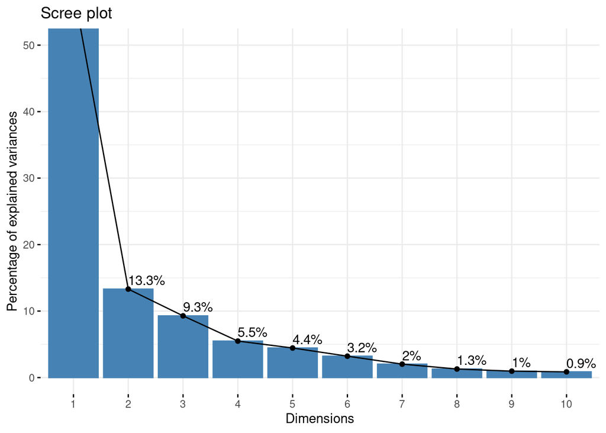

```r
fviz_eig(res.pca, addlabels = TRUE, ylim = c(0, 50))
```

### 3-Graphe des variables

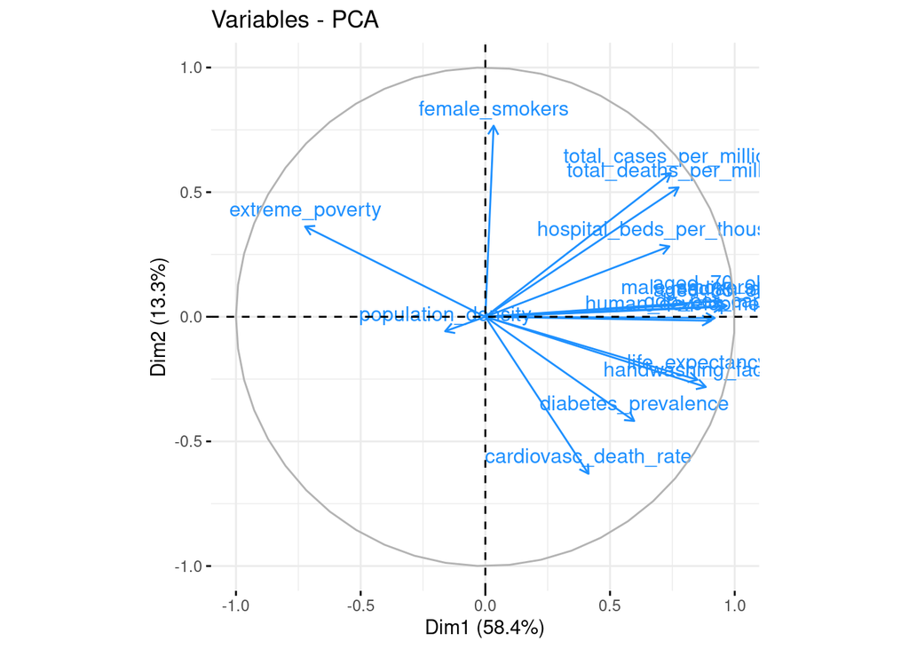

```r
fviz_pca_var(res.pca, col.var = "DodgerBlue")
```

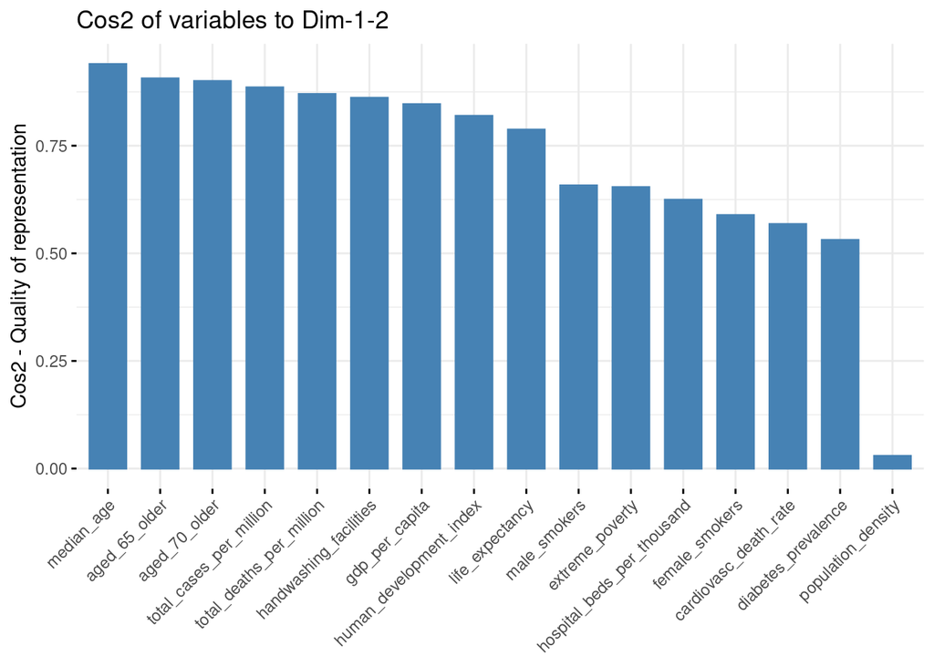

```r
fviz_cos2(res.pca, choice = "var", axes = 1:2)
```

La qualité de représentation des variables sur la carte de l’ACP s’appelle cos2 (cosinus carré). Si une variable est parfaitement représentée par seulement deux composantes principales (Dim.1& Dim.2), la somme des cos2 sur ces deux axes est égale à 1.Dans ce cas, les variables seront positionnées sur le cercle de corrélation. Pour certaines variables, plus de 2 axes peuvent être nécessaires pour représenter parfaitement les données. Dans ce cas, les variables sont positionnées à l’intérieur du cercle de corrélation. Plus une variable est proche du cercle de corrélation, meilleure est sa représentation sur la carte de l’ACP (et elle est plus importante pour interpréter les composantes principales en considération). Les variables qui sont proches du centre du graphique sont moins importantes pour les premières composantes. Dans la figure suivante nous avons une représentation en gradient de couleur des variables en fonction de leurs contributions. De ce fait, on peut voire que les variables “median_age” et “age_65_older” contribuent le plus dans l’ACP suivi des variables “aged_70_per_million” et “total_death_per_million”. La variable “population_density” est peu représenté. Ceux qui ont les memes directions sont corrélées. Comme on peut en faire le rapprochement dans le t ableau suivant le cecle de corrélation

### 5-Visualisation des variables les plus représentées dans le cercle de corrélation

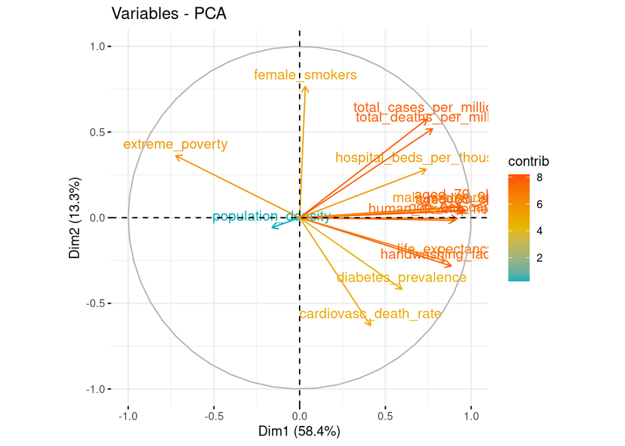

```r
fviz_pca_var(res.pca, col.var = "contrib",
             gradient.cols = c("#00AFBB", "#E7B800", "#FC4E07")
)
```

### 6-Corrélation entre les varibales

```r
cor(newData[,c("aged_65_older","aged_70_older", "total_deaths_per_million", "total_cases_per_million")])
```

```
##                          aged_65_older aged_70_older total_deaths_per_million
## aged_65_older                1.0000000     0.9931012                0.7721449
## aged_70_older                0.9931012     1.0000000                0.7807983
## total_deaths_per_million     0.7721449     0.7807983                1.0000000
## total_cases_per_million      0.7352206     0.7468694                0.9926514
##                          total_cases_per_million
## aged_65_older                          0.7352206
## aged_70_older                          0.7468694
## total_deaths_per_million               0.9926514
## total_cases_per_million                1.0000000
```

### 7-Analyse des nuages de point

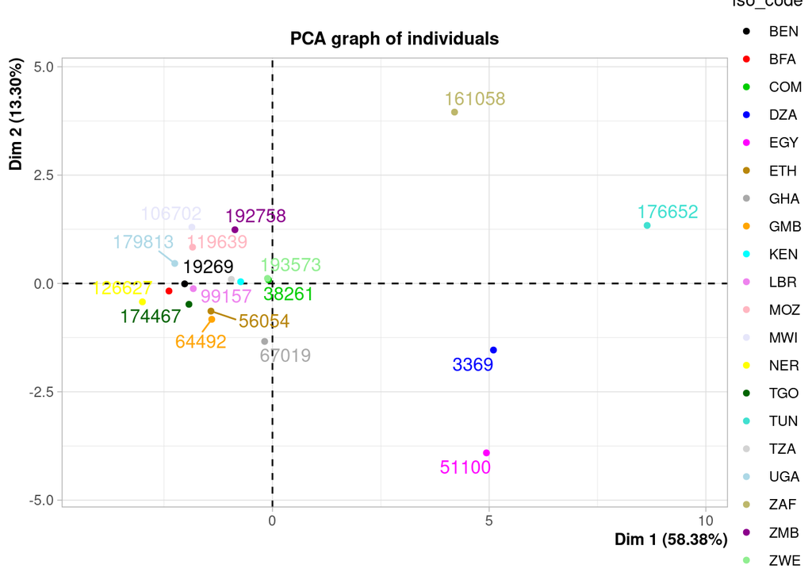

```r
res.pca1=PCA(newData, quali.sup=1:2, ncp=6, graph=FALSE)
plot(res.pca1, choix="ind", invisible = "quali", habillage = 1)
```

le principe du nuages des points individus est tel que Nous voulons, dans l’espace des variables, ajuster le nuage de n points par un sous-espace à une, puis deux dimensions, de façon à obtenir sur un graphique une représentation visuelle la plus fidèle possibledes proximités existant entre les n individus vis-à-vis des p variables. Dans notre cas il est difficille de remarquer des clusters observables.